# **Stage 1**

**In this first stage of the project, we have implemented 3 standard machine learning models integrated with historical, economic and technical data to make predictions of Brent crude oil prices. These predictions can be used to inform operational decisions, trading strategies, and financial planning.**

# **Importing the necessary libraries**

```python
import yfinance as yf
import pandas as pd
import numpy as np
from pandas_datareader import wb
import matplotlib.pyplot as plt
```

# **Collecting historical prices of Brent crude oil**

```python
# Set the time period for data collection
start_date = "2010-01-01"
end_date = "2024-11-01"
```

```python
# Download historical data for Brent crude oil from Yahoo Finance
brent = yf.download(tickers = "BZ=F",start = start_date,end =end_date,progress=False)
```

```python
# Display the first 5 rows of the dataset
brent.head(5)
```

| Price Ticker Date | Adj Close BZ=F | Close BZ=F | High BZ=F | Low BZ=F | Open BZ=F | Volume BZ=F |
| --- | --- | --- | --- | --- | --- | --- |
| 2010-01-04 | 80.120003 | 80.120003 | 79.820000 | 80.120003 | 80.120003 | 97 |
| 2010-01-05 | 80.589996 | 80.589996 | 80.260002 | 80.589996 | 80.589996 | 97 |
| 2010-01-06 | 81.889999 | 81.889999 | 81.699997 | 80.129997 | 81.129997 | 7 |
| 2010-01-07 | 81.510002 | 81.510002 | 81.510002 | 81.629997 | 81.510002 | 7 |
| 2010-01-08 | 81.370003 | 81.370003 | 81.529999 | 81.089996 | 81.370003 | 7 |

```python
# Check for missing values in the dataset
brent.isna().sum()
```

| Price | Ticker | 0 |
| --- | --- | --- |
| Adj Close | BZ=F | 0 |
| Close | BZ=F | 0 |
| High | BZ=F | 0 |
| Low | BZ=F | 0 |
| Open | BZ=F | 0 |
| Volume | BZ=F | 0 |

**dtype:** int64

```python
# Keep only the "Adjusted Close" column to focus on daily market adjusted closing prices
brent_adj_close = brent.loc[:, ['Adj Close']]
brent_adj_close.head()
```

| Price Ticker Date | Adj Close BZ=F |
| --- | --- |
| 2010-01-04 | 80.120003 |
| 2010-01-05 | 80.589996 |
| 2010-01-06 | 81.889999 |
| 2010-01-07 | 81.510002 |
| 2010-01-08 | 81.370003 |

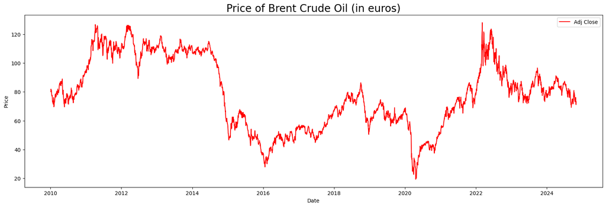

```python
# Plot the oil prices for visualization
plt.figure(figsize=(20, 6))
plt.plot(brent_adj_close.index, brent_adj_close['Adj Close'], label='Adj Close', color='r')
plt.title('Price of Brent Crude Oil (in euros)', size=20)
plt.xlabel('Date')
plt.ylabel('Price')
plt.legend()
plt.show()
```

```python
# Flatten the MultiIndex to retain only the 'Adj Close' part, excluding 'BZ=F'
df_brent_clean = brent_adj_close[('Adj Close', 'BZ=F')]

# Convert the series into a DataFrame
df_brent_clean = df_brent_clean.to_frame()

# Rename the column for clarity
df_brent_clean.columns = ['Adj Close']
```

# **Collecting and adjusting Economic Indicators data**

**The Global GDP and Inflation data retrieved from the World Bank API were available as annual values from 2010 to 2023. To integrate these indicators into the dataset, we first added forecasted values for 2024. Then, we resampled the data to a daily frequency, with missing values filled using linear interpolation. This approach ensured compatibility with the daily oil prices dataset and provided smooth transitions between annual data points.**

```python
# Fetch global inflation and gdp data from the World Bank API
inflation_data = wb.download(indicator='FP.CPI.TOTL.ZG', country='WLD', start=2009, end=2024)
gdp_data = wb.download(indicator='NY.GDP.MKTP.CD', country='WLD', start=2009, end=2024)

# Reset the index to examine available columns
inflation_data = inflation_data.reset_index()
gdp_data = gdp_data.reset_index()

# Rename columns for clarity
inflation_data = inflation_data.rename(columns={'FP.CPI.TOTL.ZG': 'Global_Inflation'})
gdp_data = gdp_data.rename(columns={'NY.GDP.MKTP.CD': 'Global_GDP'})
inflation_data = inflation_data.rename(columns={'year': 'Date'})
gdp_data = gdp_data.rename(columns={'year': 'Date'})

# Convert dates to datetime format and setting them to the last day of the year
gdp_data['Date'] = pd.to_datetime(gdp_data['Date']).apply(lambda x: x.replace(month=12, day=31))
inflation_data['Date'] = pd.to_datetime(inflation_data['Date']).apply(lambda x: x.replace(month=12, day=31))
```

```python
# Forecast GDP for 2024 based on IMF's prevision of 3% growth rate, projected linearly for 10 months
prev_gdp_2024 = gdp_data['Global_GDP'].iloc[0]*(12.3/12)

# Forecast inflation for 2024 based on OECD's prevision of 5.4% rate, projected linearly for 10 months
prev_inflation_2024 = 5.4+(2/12)*((inflation_data['Global_Inflation'].iloc[0])-5.4)
```

```python
# Add the forecasted GDP and inflation for end of 2024
new_gdp_row = pd.DataFrame({'Date': ['2024-10-31'], 'Global_GDP': [prev_gdp_2024]})
new_inflation_row = pd.DataFrame({'Date': ['2024-10-31'], 'Global_Inflation': [prev_inflation_2024]})

# Concatenate the new row to the original data
gdp_data = pd.concat([new_gdp_row, gdp_data.reset_index()], ignore_index=True)
inflation_data = pd.concat([new_inflation_row, inflation_data.reset_index()], ignore_index=True)

# Reset the 'Date' column as the index
gdp_data['Date'] = pd.to_datetime(gdp_data['Date'])
gdp_data = gdp_data.set_index('Date')

inflation_data['Date'] = pd.to_datetime(inflation_data['Date'])
inflation_data = inflation_data.set_index('Date')

print(gdp_data)
print("\n",inflation_data)
```

```
              Global_GDP  index country
Date
2024-10-31  1.080709e+14    NaN     NaN
2023-12-31  1.054350e+14    0.0   World
2022-12-31  1.012251e+14    1.0   World
2021-12-31  9.752703e+13    2.0   World
2020-12-31  8.557772e+13    3.0   World
2019-12-31  8.794557e+13    4.0   World
2018-12-31  8.668687e+13    5.0   World
2017-12-31  8.155096e+13    6.0   World
2016-12-31  7.658803e+13    7.0   World
2015-12-31  7.535966e+13    8.0   World
2014-12-31  7.989439e+13    9.0   World
2013-12-31  7.775137e+13   10.0   World
2012-12-31  7.560398e+13   11.0   World
2011-12-31  7.395779e+13   12.0   World
2010-12-31  6.651417e+13   13.0   World
2009-12-31  6.071826e+13   14.0   World

             Global_Inflation  index country
Date
2024-10-31          5.448526    NaN     NaN
2023-12-31          5.691153    0.0   World
2022-12-31          7.967574    1.0   World
2021-12-31          3.466926    2.0   World
2020-12-31          1.920968    3.0   World
2019-12-31          2.206073    4.0   World
2018-12-31          2.450362    5.0   World
2017-12-31          2.254277    6.0   World
2016-12-31          1.605539    7.0   World
2015-12-31          1.443857    8.0   World
2014-12-31          2.354491    9.0   World
2013-12-31          2.651673   10.0   World
2012-12-31          3.725327   11.0   World
2011-12-31          4.822396   12.0   World
2010-12-31          3.326345   13.0   World
2009-12-31          2.860449   14.0   World
```

# **Linearly interpolating to generate daily data for GDP and inflation**

```python
# Resample annual data to daily frequency
gdp_data_daily = gdp_data.resample('D').asfreq()
inflation_data_daily = inflation_data.resample('D').asfreq()

# Linearly interpolate missing values
gdp_data_daily['Global_GDP'] = gdp_data_daily['Global_GDP'].interpolate(method='linear')
inflation_data_daily['Global_Inflation'] = inflation_data_daily['Global_Inflation'].interpolate(method='linear')


# Remove unnecessary columns if they exist
gdp_data_daily = gdp_data_daily.drop(columns=["country"], errors='ignore')
inflation_data_daily =inflation_data_daily.drop(columns=["country"], errors='ignore')

gdp_data_daily = gdp_data_daily.drop(columns=["index"], errors='ignore')
inflation_data_daily =inflation_data_daily.drop(columns=["index"], errors='ignore')


# Remove the 2009-12-31 row to match the timeframe
gdp_data_daily = gdp_data_daily.drop(index='2009-12-31')
inflation_data_daily =inflation_data_daily.drop(index='2009-12-31')
```

```python
# Remove timezone information from the index
df_brent_clean.index = df_brent_clean.index.tz_localize(None)


df_brent = brent_adj_close.copy()

# Merge the datasets based on the 'Date' column
df_brent = pd.merge(df_brent_clean, gdp_data_daily, on='Date', how='inner')
df_brent = pd.merge(df_brent, inflation_data_daily, on='Date', how='inner')

# Display the resulting DataFrame
df_brent
```

| Date | Adj Close | Global_GDP | Global_Inflation |
| --- | --- | --- | --- |
| 2010-01-04 | 80.120003 | 6.078178e+13 | 2.865554 |
| 2010-01-05 | 80.589996 | 6.079766e+13 | 2.866831 |
| 2010-01-06 | 81.889999 | 6.081354e+13 | 2.868107 |
| 2010-01-07 | 81.510002 | 6.082942e+13 | 2.869384 |
| 2010-01-08 | 81.370003 | 6.084530e+13 | 2.870660 |
| ... | ... | ... | ... |
| 2024-10-25 | 76.050003 | 1.080191e+14 | 5.453299 |
| 2024-10-28 | 71.419998 | 1.080450e+14 | 5.450912 |
| 2024-10-29 | 71.120003 | 1.080536e+14 | 5.450117 |
| 2024-10-30 | 72.550003 | 1.080623e+14 | 5.449321 |
| 2024-10-31 | 73.160004 | 1.080709e+14 | 5.448526 |

3700 rows × 3 columns

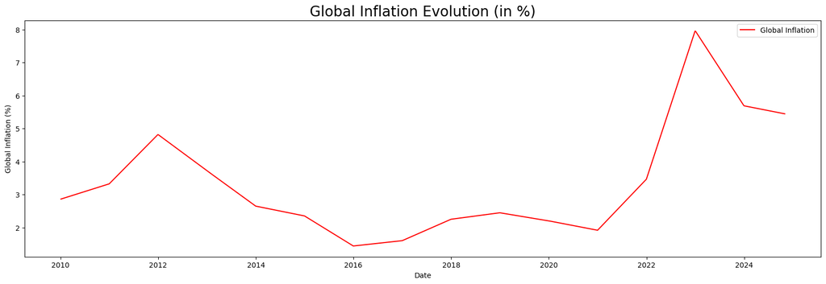

```python
# Plot of Global Inflation after linear interpolation for visualization
plt.figure(figsize=(20, 6))
plt.plot(df_brent.index, df_brent['Global_Inflation'], label='Global Inflation', color='r')
plt.title('Global Inflation Evolution (in %)', size=20)
plt.xlabel('Date')
plt.ylabel('Global Inflation (%)')
plt.legend()
plt.show()
```

# **Adding Returns over the horizon 1-10 days**

**We then calculated the oil price returns on different horizons as well as technical indicators. The idea behind this is to provide models with data that can help detect trends in past values, increasing the accuracy of predictions.**

```python
# Calculate the returns
for i in range(1, 11):
    df_brent[f'rendement_{i}_jours'] = df_brent['Adj Close'].pct_change(periods=i)

# Display the first results
df_brent.head(11)
```

| Date | Adj Close | Global_GDP | Global_Inflation | rendement_1_jours | rendement_2_jours | rendement_3_jours | rendement_4_jours | rendement_5_jours | rendement_6_jours | rendement_7_jours | rendement_8_jours | rendement_9_jours | rendement_10_jours |
| --- | --- | --- | --- | --- | --- | --- | --- | --- | --- | --- | --- | --- | --- |
| 2010-01-04 | 80.120003 | 6.078178e+13 | 2.865554 | NaN | NaN | NaN | NaN | NaN | NaN | NaN | NaN | NaN | NaN |
| 2010-01-05 | 80.589996 | 6.079766e+13 | 2.866831 | 0.005866 | NaN | NaN | NaN | NaN | NaN | NaN | NaN | NaN | NaN |
| 2010-01-06 | 81.889999 | 6.081354e+13 | 2.868107 | 0.016131 | 0.022092 | NaN | NaN | NaN | NaN | NaN | NaN | NaN | NaN |
| 2010-01-07 | 81.510002 | 6.082942e+13 | 2.869384 | -0.004640 | 0.011416 | 0.017349 | NaN | NaN | NaN | NaN | NaN | NaN | NaN |
| 2010-01-08 | 81.370003 | 6.084530e+13 | 2.870660 | -0.001718 | -0.006350 | 0.009679 | 0.015602 | NaN | NaN | NaN | NaN | NaN | NaN |
| 2010-01-11 | 80.970001 | 6.089293e+13 | 2.874489 | -0.004916 | -0.006625 | -0.011235 | 0.004715 | 0.010609 | NaN | NaN | NaN | NaN | NaN |
| 2010-01-12 | 79.300003 | 6.090881e+13 | 2.875766 | -0.020625 | -0.025439 | -0.027113 | -0.031628 | -0.016007 | -0.010235 | NaN | NaN | NaN | NaN |
| 2010-01-13 | 78.309998 | 6.092469e+13 | 2.877042 | -0.012484 | -0.032852 | -0.037606 | -0.039259 | -0.043717 | -0.028291 | -0.022591 | NaN | NaN | NaN |
| 2010-01-14 | 77.820000 | 6.094057e+13 | 2.878319 | -0.006257 | -0.018663 | -0.038903 | -0.043628 | -0.045271 | -0.049701 | -0.034371 | -0.028707 | NaN | NaN |
| 2010-01-15 | 77.110001 | 6.095645e+13 | 2.879595 | -0.009124 | -0.015324 | -0.027617 | -0.047672 | -0.052353 | -0.053981 | -0.058371 | -0.043181 | -0.037569 | NaN |
| 2010-01-19 | 77.629997 | 6.101997e+13 | 2.884701 | 0.006744 | -0.002442 | -0.008683 | -0.021059 | -0.041250 | -0.045963 | -0.047602 | -0.052021 | -0.036729 | -0.031078 |

# **SMA (Simple Moving Average) Calculation**

```python
# Drop SMA20 and SMA50 columns if they exist
df_brent = df_brent.drop(columns=['SMA20', 'SMA50'], errors='ignore')

# Calculate the 20-day SMA
df_brent['SMA20'] = df_brent['Adj Close'].rolling(window=20).mean()

# Calculate the 50-day SMA
df_brent['SMA50'] = df_brent['Adj Close'].rolling(window=50).mean()
```

# **RSI (Relative Strength Index) Calculation**

```python
# Calculate daily price differences
delta = df_brent['Adj Close'].diff()

# Separate the gains and losses
gain = delta.where(delta > 0, 0)  # Gains (losses are replaced by 0)
loss = -delta.where(delta < 0, 0) # Losses (gains are replaced by 0)


# Calculate the 14-day exponential moving average of gains and losses
avg_gain = gain.rolling(window=14).mean()
avg_loss = loss.rolling(window=14).mean()

# Calculate RSI using the formula
rs = avg_gain / avg_loss
df_brent = df_brent.drop(columns=['RSI'], errors='ignore')
df_brent['RSI'] = 100 - (100 / (1 + rs))
```

# **MACD (Moving Average Convergence Divergence) and Signal Line Calculation**

```python
# Drop MACD and Signal_Line columns if they exist
df_brent = df_brent.drop(columns=['MACD','Signal_Line'], errors='ignore')

# Calculate the MACD: the difference between the EMA12 and EMA26
df_brent['MACD'] = df_brent['Adj Close'].ewm(span=12, adjust=False).mean() - df_brent['Adj Close'].ewm(span=26, adjust=False).mean()

# Calculate the Signal Line: the EMA9 of the MACD
df_brent['Signal_Line'] = df_brent['MACD'].ewm(span=9, adjust=False).mean()
```

# **BOLLINGER BANDS Calculation**

```python
# Drop Upper_Band and Lower_Band columns if they exist
df_brent = df_brent.drop(columns=['Upper_Band','Lower_Band'], errors = "ignore")

# Calculate the upper and lower bands directly
df_brent['Upper_Band'] = df_brent['Adj Close'].rolling(window=20).mean() + 2 * df_brent['Adj Close'].rolling(window=20).std()
df_brent['Lower_Band'] = df_brent['Adj Close'].rolling(window=20).mean() - 2 * df_brent['Adj Close'].rolling(window=20).std()
```

```python
# Display the last values of the dataframe to check the technical indicators
df_brent.tail(10)
```

| Date | Adj Close | Global_GDP | Global_Inflation | rendement_1_jours | rendement_2_jours | rendement_3_jours | rendement_4_jours | rendement_5_jours | rendement_6_jours | rendement_7_jours | rendement_8_jours | rendement_9_jours | rendement_10_jours | SMA20 | SMA50 | RSI | MACD | Signal_Line | Upper_Band | Lower_Band |
| --- | --- | --- | --- | --- | --- | --- | --- | --- | --- | --- | --- | --- | --- | --- | --- | --- | --- | --- | --- | --- |
| 2024-10-18 | 73.059998 | 1.079586e+14 | 5.458867 | -0.018670 | -0.015629 | -0.016027 | -0.056804 | -0.075658 | -0.079849 | -0.045965 | -0.053382 | -0.097245 | -0.063933 | 75.379000 | 75.8224 | 52.788589 | -0.042236 | 0.246920 | 80.821242 | 69.936759 |
| 2024-10-21 | 74.290001 | 1.079845e+14 | 5.456481 | 0.016836 | -0.002149 | 0.000943 | 0.000539 | -0.040924 | -0.060096 | -0.064358 | -0.029903 | -0.037445 | -0.082046 | 75.398500 | 75.7150 | 51.617198 | -0.133099 | 0.170916 | 80.821188 | 69.975812 |
| 2024-10-22 | 76.040001 | 1.079931e+14 | 5.455685 | 0.023556 | 0.040788 | 0.021357 | 0.024522 | 0.024108 | -0.018332 | -0.037955 | -0.042317 | -0.007051 | -0.014771 | 75.442000 | 75.5898 | 54.462051 | -0.063170 | 0.124099 | 80.870925 | 70.013076 |
| 2024-10-23 | 74.959999 | 1.080018e+14 | 5.454890 | -0.014203 | 0.009019 | 0.026006 | 0.006850 | 0.009970 | 0.009562 | -0.032275 | -0.051619 | -0.055919 | -0.021154 | 75.517000 | 75.4752 | 43.767563 | -0.093817 | 0.080515 | 80.871571 | 70.162429 |
| 2024-10-24 | 74.379997 | 1.080104e+14 | 5.454094 | -0.007737 | -0.021831 | 0.001211 | 0.018067 | -0.000940 | 0.002156 | 0.001751 | -0.039762 | -0.058958 | -0.063224 | 75.656000 | 75.3676 | 41.461130 | -0.163027 | 0.031807 | 80.718821 | 70.593179 |
| 2024-10-25 | 76.050003 | 1.080191e+14 | 5.453299 | 0.022452 | 0.014541 | 0.000132 | 0.023691 | 0.040925 | 0.021491 | 0.024656 | 0.024242 | -0.018203 | -0.037829 | 75.859500 | 75.2678 | 37.968452 | -0.082173 | 0.009011 | 80.618244 | 71.100756 |
| 2024-10-28 | 71.419998 | 1.080450e+14 | 5.450912 | -0.060881 | -0.039796 | -0.047225 | -0.060758 | -0.038632 | -0.022447 | -0.040698 | -0.037726 | -0.038115 | -0.077976 | 75.842000 | 75.1026 | 36.389416 | -0.387235 | -0.070238 | 80.666190 | 71.017811 |
| 2024-10-29 | 71.120003 | 1.080536e+14 | 5.450117 | -0.004200 | -0.064826 | -0.043829 | -0.051227 | -0.064703 | -0.042671 | -0.026553 | -0.044728 | -0.041768 | -0.042155 | 75.720000 | 74.9718 | 36.912759 | -0.645762 | -0.185343 | 80.897642 | 70.542359 |
| 2024-10-30 | 72.550003 | 1.080623e+14 | 5.449321 | 0.020107 | 0.015822 | -0.046022 | -0.024603 | -0.032150 | -0.045897 | -0.023422 | -0.006980 | -0.025520 | -0.022501 | 75.652501 | 74.8788 | 32.408846 | -0.726878 | -0.293650 | 80.963526 | 70.341475 |
| 2024-10-31 | 73.160004 | 1.080709e+14 | 5.448526 | 0.008408 | 0.028684 | 0.024363 | -0.038001 | -0.016402 | -0.024013 | -0.037875 | -0.015211 | 0.001369 | -0.017327 | 75.429501 | 74.8210 | 35.091292 | -0.733487 | -0.381617 | 80.767155 | 70.091847 |

# **Pre-processing**

**The calculation of rolling indicators such as returns, moving averages (SMA20, SMA50), and technical indicators like RSI and Bollinger Bands, which require a certain number of prior data points, led to the appearance of missing values in the first rows of the dataset.**

**To handle these missing values effectively, rows with more than 20% missing values were removed, ensuring a cleaner dataset for analysis. For remaining gaps, such as in the SMA50 column, missing values were filled with the column’s mean to maintain consistency without distorting trends. This approach effectively managed missing data while preserving the dataset’s integrity for modeling.**

```python
# Check for missing values
df_brent.isna().sum()
```

|  | 0 |
| --- | --- |
| Adj Close | 0 |
| Global_GDP | 0 |
| Global_Inflation | 0 |
| rendement_1_jours | 1 |
| rendement_2_jours | 2 |
| rendement_3_jours | 3 |
| rendement_4_jours | 4 |
| rendement_5_jours | 5 |
| rendement_6_jours | 6 |
| rendement_7_jours | 7 |
| rendement_8_jours | 8 |
| rendement_9_jours | 9 |
| rendement_10_jours | 10 |
| SMA20 | 19 |
| SMA50 | 49 |
| RSI | 13 |
| MACD | 0 |
| Signal_Line | 0 |
| Upper_Band | 19 |
| Lower_Band | 19 |

**dtype:** int64

```python
# Display the rate of missing values by rows
missing_values_rate_by_row = (df_brent.isnull().sum(axis=1) / df_brent.shape[1]) * 100
print("\nRate of Missing Values by Row")
missing_values_rate_by_row.head(50)
```

```
Rate of Missing Values by Row
```

| Date | 0 |
| --- | --- |
| 2010-01-04 | 75.0 |
| 2010-01-05 | 70.0 |
| 2010-01-06 | 65.0 |
| 2010-01-07 | 60.0 |
| 2010-01-08 | 55.0 |
| 2010-01-11 | 50.0 |
| 2010-01-12 | 45.0 |
| 2010-01-13 | 40.0 |
| 2010-01-14 | 35.0 |
| 2010-01-15 | 30.0 |
| 2010-01-19 | 25.0 |
| 2010-01-20 | 25.0 |
| 2010-01-21 | 25.0 |
| 2010-01-22 | 20.0 |
| 2010-01-25 | 20.0 |
| 2010-01-26 | 20.0 |
| 2010-01-27 | 20.0 |
| 2010-01-28 | 20.0 |
| 2010-01-29 | 20.0 |
| 2010-02-01 | 5.0 |
| 2010-02-02 | 5.0 |
| 2010-02-03 | 5.0 |
| 2010-02-04 | 5.0 |
| 2010-02-05 | 5.0 |
| 2010-02-08 | 5.0 |
| 2010-02-09 | 5.0 |
| 2010-02-10 | 5.0 |
| 2010-02-11 | 5.0 |
| 2010-02-12 | 5.0 |
| 2010-02-16 | 5.0 |
| 2010-02-17 | 5.0 |
| 2010-02-18 | 5.0 |
| 2010-02-19 | 5.0 |
| 2010-02-22 | 5.0 |
| 2010-02-23 | 5.0 |
| 2010-02-24 | 5.0 |
| 2010-02-25 | 5.0 |
| 2010-02-26 | 5.0 |
| 2010-03-01 | 5.0 |
| 2010-03-02 | 5.0 |
| 2010-03-03 | 5.0 |
| 2010-03-04 | 5.0 |
| 2010-03-05 | 5.0 |
| 2010-03-08 | 5.0 |
| 2010-03-09 | 5.0 |
| 2010-03-10 | 5.0 |
| 2010-03-11 | 5.0 |
| 2010-03-12 | 5.0 |
| 2010-03-15 | 5.0 |
| 2010-03-16 | 0.0 |

**dtype:** float64

```python
#removing every rows with more than 20% missing values
df_brent_pre_pro = df_brent[missing_values_rate_by_row < 20]
```

```python
print(df_brent_pre_pro.isna().sum())
print(df_brent_pre_pro.shape)
```

```
Adj Close              0
Global_GDP             0
Global_Inflation       0
rendement_1_jours      0
rendement_2_jours      0
rendement_3_jours      0
rendement_4_jours      0
rendement_5_jours      0
rendement_6_jours      0
rendement_7_jours      0
rendement_8_jours      0
rendement_9_jours      0
rendement_10_jours     0
SMA20                  0
SMA50                 30
RSI                    0
MACD                   0
Signal_Line            0
Upper_Band             0
Lower_Band             0
dtype: int64
(3681, 20)
```

```python
# Calculate the mean value of the SMA50 column
mean_SMA50 = df_brent_pre_pro['SMA50'].mean()

# Fill missing values in the "SMA50" column with the mean
df_brent_pre_pro['SMA50'].fillna(mean_SMA50, inplace=True)
print(df_brent_pre_pro.isna().sum())
```

```
Adj Close             0
Global_GDP            0
Global_Inflation      0
rendement_1_jours     0
rendement_2_jours     0
rendement_3_jours     0
rendement_4_jours     0
rendement_5_jours     0
rendement_6_jours     0
rendement_7_jours     0
rendement_8_jours     0
rendement_9_jours     0
rendement_10_jours    0
SMA20                 0
SMA50                 0
RSI                   0
MACD                  0
Signal_Line           0
Upper_Band            0
Lower_Band            0
dtype: int64
```

# **Linear Regression**

**We first selected linear regression as a baseline model due to its simplicity, interpretability, suitability with time series data, and because we have already used it in class.**

**But this model has also some limitations. Linear regression assumes linear relationships between features and the target variable. This may oversimplify the problem if the dataset contains non-linear interactions. Additionally, the model’s performance could degrade in the presence of big shocks or regime switching, which often happen with financial data.**

**Because we are dealing with time series data, we split the data sequentially into training and testing sets instead of a random split. This method ensures a chronological separation to simulate real-world forecasting.**

**In order to monitor under-/over-fitting and maximize the model's performance, we evaluated different training sizes (50% to 90%) to determine the optimal data split for minimizing bias and variance, and we compared training and testing MSE.**

```python
from sklearn.model_selection import train_test_split
from sklearn.preprocessing import StandardScaler
from sklearn.linear_model import LinearRegression
from sklearn.metrics import mean_squared_error, r2_score, mean_absolute_error, root_mean_squared_error
```

```python
# We split the dataset into two: X for features and Y for the variable we want to predict
X,y = df_brent_pre_pro.drop(columns=['Adj Close']), df_brent_pre_pro['Adj Close']
```

```python
# Different training sizes to test for overfitting control (from 50% to 90% of the data for training)
train_sizes = [0.5, 0.6, 0.7, 0.8, 0.9]
results = []

for train_size in train_sizes:

  split_index = int(len(X) * train_size)  # Split index

  # Split training and test set
  x_train, x_test = X[:split_index], X[split_index:]
  y_train, y_test = y[:split_index], y[split_index:]

  # Create the model and fit to the data
  linear_regression_model = LinearRegression()
  linear_regression_model.fit(x_train, y_train)


  # Predictions on the training and test sets
  y_train_pred = linear_regression_model.predict(x_train)
  y_test_pred = linear_regression_model.predict(x_test)


  # Calculate errors to evaluate bias and variance
  train_mse = mean_squared_error(y_train, y_train_pred)
  test_mse = mean_squared_error(y_test, y_test_pred)
  r2_train = r2_score(y_train, y_train_pred)
  r2_test = r2_score(y_test, y_test_pred)

  # Calculate bias (mean training error) and variance (difference between test and train errors)
  bias = train_mse
  variance = abs(test_mse - train_mse)

  # Store results
  results.append({
      "train_size": train_size,
      "train_mse": train_mse,
      "test_mse": test_mse,
      "r2_train": r2_train,
      "r2_test": r2_test,
      "bias": bias,
      "variance": variance
  })
```

```python
# Find the best training size that minimizes bias and variance
best_result = min(results, key=lambda x: (x['bias'], x['variance']))
```

```python
# Display the results
for res in results:
    print(f"Train size: {res['train_size']*100}% | Train MSE: {res['train_mse']:.4f} | Test MSE: {res['test_mse']:.4f} | "
          f"R2 Train: {res['r2_train']:.4f} | R2 Test: {res['r2_test']:.4f} | Bias: {res['bias']:.4f} | Variance: {res['variance']:.4f}")

print("\nBest train size minimizing bias and variance:")
print(f"Train size: {best_result['train_size']*100}% | Bias: {best_result['bias']:.4f} | Variance: {best_result['variance']:.4f}")
```

```
Train size: 50.0% | Train MSE: 0.1725 | Test MSE: 0.4992 | R2 Train: 0.9998 | R2 Test: 0.9984 | Bias: 0.1725 | Variance: 0.3267
Train size: 60.0% | Train MSE: 0.1526 | Test MSE: 0.4680 | R2 Train: 0.9998 | R2 Test: 0.9987 | Bias: 0.1526 | Variance: 0.3154
Train size: 70.0% | Train MSE: 0.2103 | Test MSE: 0.5958 | R2 Train: 0.9997 | R2 Test: 0.9981 | Bias: 0.2103 | Variance: 0.3854
Train size: 80.0% | Train MSE: 0.1969 | Test MSE: 0.6682 | R2 Train: 0.9997 | R2 Test: 0.9951 | Bias: 0.1969 | Variance: 0.4712
Train size: 90.0% | Train MSE: 0.2826 | Test MSE: 0.1111 | R2 Train: 0.9996 | R2 Test: 0.9964 | Bias: 0.2826 | Variance: 0.1715

Best train size minimizing bias and variance:
Train size: 60.0% | Bias: 0.1526 | Variance: 0.3154
```

```python
split_index = int(len(X) * best_result['train_size'])  # Split index with best size (60%)

# Split training and test set
x_train, x_test = X[:split_index], X[split_index:]
y_train, y_test = y[:split_index], y[split_index:]

# Create the model
linear_regression_model = LinearRegression()
linear_regression_model.fit(x_train, y_train)

# We predict the value of the test set
y_pred_linear_reg = linear_regression_model.predict(x_test)


# Convert y_pred into a DataFrame with the same index as x_test to keep the dates
y_pred_linear_reg_df = pd.DataFrame(y_pred_linear_reg, index=x_test.index, columns=['Prix_Prédit'])
```

```python
# Quantify the errors
mse_linear_regression = mean_squared_error(y_test, y_pred_linear_reg)
r2 = r2_score(y_test, y_pred_linear_reg)
mae = mean_absolute_error(y_test, y_pred_linear_reg)
rmse = root_mean_squared_error(y_test, y_pred_linear_reg)

print("R2 : ",r2)
print("MSE : ", mse_linear_regression)
print("MAE : ",mae)
print("RMSE : ",rmse)
```

```
R2 :  0.9987381287588201
MSE :  0.4679951848857247
MAE :  0.3983337885500437
RMSE :  0.6841017357716064
```

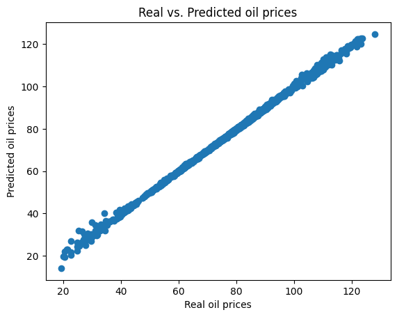

```python
# Visualizing the predicted vs actual values
plt.scatter(y_test, y_pred_linear_reg)
plt.xlabel("Real oil prices")
plt.ylabel("Predicted oil prices")
plt.title("Real vs. Predicted oil prices")
plt.show()
```

```python
# Extract the weights and intercept of the linear regression model
coefficients = linear_regression_model.coef_
intercept = linear_regression_model.intercept_

# Display the weights and intercept
print("Coefficients (Weights):", coefficients)
print("Intercept (Bias):", intercept)
```

```
Coefficients (Weights): [-4.27106749e-15 -4.15826102e-02  1.81439642e+01  1.30717475e+01
  5.90208760e+00  3.25356463e+00  1.53170854e+00 -7.35505081e-01
 -5.09899155e-01 -1.23807185e+00 -8.56683295e-01 -2.53128673e+00
  3.73071103e-01 -1.17005937e-01  1.20199080e-02  5.53796823e+00
 -4.68304363e+00  3.69322715e-01  3.76819491e-01]
Intercept (Bias): -0.3179013284858314
```

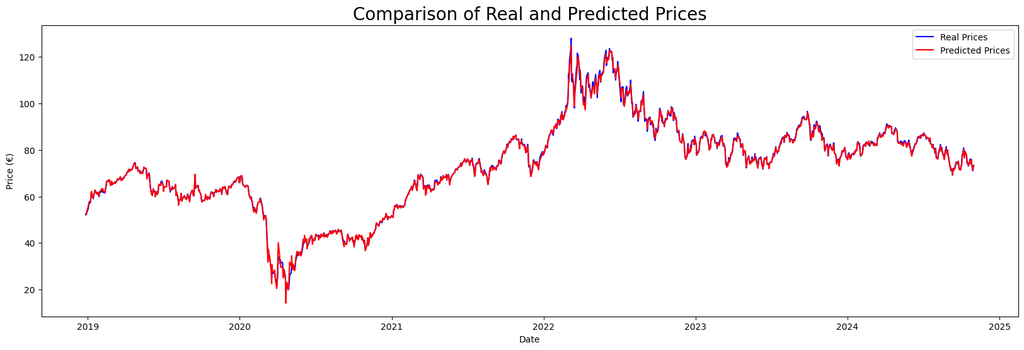

```python
# Plot Real and predicted prices together for comparison
plt.figure(figsize=(20, 6))

plt.plot(y_test, label='Real Prices', color='blue')
plt.plot(y_pred_linear_reg_df, label='Predicted Prices', color='red')

plt.xlabel('Date')
plt.ylabel('Price (€)')
plt.title('Comparison of Real and Predicted Prices',size=20)
plt.legend()
plt.show()
```

**As we can see with the plot, the linear regression model achieves a really good performance for this dataset.**

**The best training size to mitigate over-fitting without compromising the performance was identified at 60%.**

**The different metrics calculated highlight the model’s accuracy :**

- **R2 score : 0.9987, indicating that the model explains 99.87% of the variance in the prices.**
- **MSE : 0.468, MAE : 0.398, RMSE : 0.684, reflecting a low average squared, absolute, and root squared error in predictions.**

**However, the gap between training and testing MSE values (0.1526 vs. 0.468 at the optimal split) suggests that there may still be a little bit of overfitting, so we can potentialy find an even better model for this dataset.**

# **Decision Tree Regressor**

**We then decided to implement the Decision Tree model. While we studied the Decision Tree Classifier in class, it was not suitable for our project and objectives. Instead, the Decision Tree Regressor was more appropriate because our task involves regression, not classification.**

**We selected this model for its ability to model non-linear relationships, which may exist in the dataset. However, decision trees are prone to overfitting, as we will see in the results.**

**For the model’s implementation with our data, we followed a similar approach as with linear regression: sequential data splitting, comparison of training and testing MSE, evaluation of diffferent training sizes to minimize bias and variance/control overfitting, etc.**

```python
from sklearn.tree import DecisionTreeRegressor, plot_tree
from sklearn.model_selection import train_test_split, cross_val_score
```

```python
# We split the dataset into two: one X for the features and one Y for the variable we want to predict
X,y = df_brent_pre_pro.drop(columns=['Adj Close']), df_brent_pre_pro['Adj Close']
```

```python
# Different training sizes to test for overfitting control (from 50% to 90% of the data for training)
train_sizes = [0.5, 0.6, 0.7, 0.8, 0.9]
results = []

for train_size in train_sizes:

  split_index = int(len(X) * train_size)  # Split index

  # Split training and test set
  x_train, x_test = X[:split_index], X[split_index:]
  y_train, y_test = y[:split_index], y[split_index:]

  # Create the model
  decision_tree = DecisionTreeRegressor()
  decision_tree.fit(x_train, y_train) #train our decision tree


  # Predictions on the training and test sets
  y_train_pred = decision_tree.predict(x_train)
  y_test_pred = decision_tree.predict(x_test)


  # Calculate errors to evaluate bias and variance
  train_mse = mean_squared_error(y_train, y_train_pred)
  test_mse = mean_squared_error(y_test, y_test_pred)
  r2_train = r2_score(y_train, y_train_pred)
  r2_test = r2_score(y_test, y_test_pred)

  # Calculate bias (mean training error) and variance (difference between test and train errors)
  bias = train_mse
  variance = abs(test_mse - train_mse)

  # Store results
  results.append({
      "train_size": train_size,
      "train_mse": train_mse,
      "test_mse": test_mse,
      "r2_train": r2_train,
      "r2_test": r2_test,
      "bias": bias,
      "variance": variance
  })
```

```python
# Find the best training size that minimizes bias and variance
best_result = min(results, key=lambda x: (x['bias'], x['variance']))
```

```python
# Display the results
for res in results:
    print(f"Train size: {res['train_size']*100}% | Train MSE: {res['train_mse']:.4f} | Test MSE: {res['test_mse']:.4f} | "
          f"R2 Train: {res['r2_train']:.4f} | R2 Test: {res['r2_test']:.4f} | Bias: {res['bias']:.4f} | Variance: {res['variance']:.4f}")

print("\nBest train size minimizing bias and variance:")
print(f"Train size: {best_result['train_size']*100}% | Bias: {best_result['bias']:.4f} | Variance: {best_result['variance']:.4f}")
```

```
Train size: 50.0% | Train MSE: 0.0000 | Test MSE: 37.6295 | R2 Train: 1.0000 | R2 Test: 0.8822 | Bias: 0.0000 | Variance: 37.6295
Train size: 60.0% | Train MSE: 0.0000 | Test MSE: 23.6805 | R2 Train: 1.0000 | R2 Test: 0.9361 | Bias: 0.0000 | Variance: 23.6805
Train size: 70.0% | Train MSE: 0.0000 | Test MSE: 18.2311 | R2 Train: 1.0000 | R2 Test: 0.9432 | Bias: 0.0000 | Variance: 18.2311
Train size: 80.0% | Train MSE: 0.0000 | Test MSE: 19.2164 | R2 Train: 1.0000 | R2 Test: 0.8590 | Bias: 0.0000 | Variance: 19.2164
Train size: 90.0% | Train MSE: 0.0000 | Test MSE: 4.5779 | R2 Train: 1.0000 | R2 Test: 0.8517 | Bias: 0.0000 | Variance: 4.5779

Best train size minimizing bias and variance:
Train size: 90.0% | Bias: 0.0000 | Variance: 4.5779
```

```python
split_index = int(len(X) * best_result['train_size'])  # Split index with best size (90%)

# Split training and test set
x_train, x_test = X[:split_index], X[split_index:]
y_train, y_test = y[:split_index], y[split_index:]

# Create the model
decision_tree = DecisionTreeRegressor()
decision_tree.fit(x_train, y_train) #train our decision tree

# We predict the value of the test set
y_pred_tree = decision_tree.predict(x_test)
# Convert y_pred into a DataFrame with the same index as x_test to keep the dates
y_pred_tree_df = pd.DataFrame(y_pred_tree, index=x_test.index, columns=['Prix_Prédit'])
```

```python
# Quantify the errors
accuracy = decision_tree.score(x_test, y_test)

mse = mean_squared_error(y_test, y_pred_tree)
mae = mean_absolute_error(y_test, y_pred_tree)
rmse = root_mean_squared_error(y_test, y_pred_tree)

print("R2 : ", accuracy)
print("MSE : ", mse)
print("MAE : ",mae)
print("RMSE : ",rmse)
```

```
R2 :  0.8564111683341351
MSE :  4.432079112753815
MAE :  1.6750948939543107
RMSE :  2.10525036818755
```

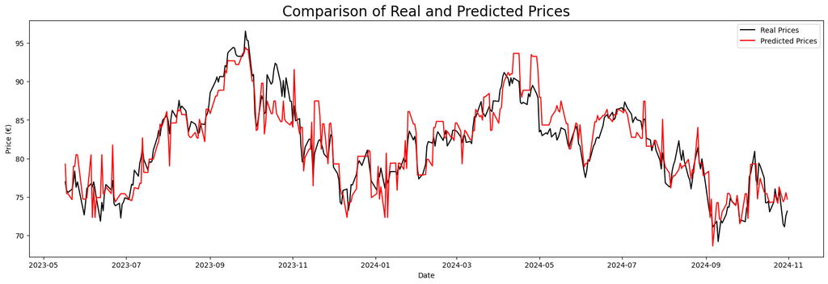

```python
# Plot Real and predicted prices together for comparison
plt.figure(figsize=(20, 6))

plt.plot(y_test, label='Real Prices', color='black')
plt.plot(y_pred_tree_df, label='Predicted Prices', color='red')

plt.xlabel('Date')
plt.ylabel('Price (€)')
plt.title('Comparison of Real and Predicted Prices',size=20)
plt.legend()
plt.show()
```

**When we compared the MSE on the training set and the test set, we saw that the model achieved perfect performance on the training set (MSE was consistently 0.0) but considerably lower performance on the test set, which highlights overfitting.**

**To address this, we experimented with regularizing the model by setting hyperparameters, such as fixing a maximum depth for the tree. This resulted in a non-zero MSE on the training set, which initially seemed promising. However, the MSE on the test predictions worsened, suggesting that the regularization did not improve generalization. So we retained the original model without any hyperparameter constraints and found the best training size to minimize bias and variance to be at 90%.**

# **K-Cross Validation**

**With the desire to reduce overfitting in the decision tree regressor, we decided to implement K-cross validation to the decision tree model as the final step of this stage. This method evaluates the model’s performance on multiple subsets of the data, providing a more robust estimate of its generalization capabilities.**

**We implemented this model with the following method :**

1. **The dataset is split into k subsets (folds).**
2. **In each iteration, one fold is used as the test set, while the remaining k-1 folds serve as the training set.**
3. **Performance metrics (R², MSE, MAE, RMSE) are calculated for each fold.**
4. **The final performance is derived by averaging these metrics across all k iterations.**

**To optimize this model, we introduced a hyperparameter: the best number of folds (k). To achieve that, we implemented a loop evaluating the average R2 score for each values of k, ranging from 2 to 10, and selected the value that maximized the model’s performance.**

```python
from sklearn.model_selection import KFold
from sklearn.metrics import accuracy_score
```

```python
def kfoldCrossValidation(X,y,M,k,test):
  # Set up k-fold cross-validation
  kfold = KFold(n_splits=k, shuffle=False)
  score_r2 = []
  score_mse = []
  score_mae = []
  score_rmse = []
  fold = 0
  # Perform k-fold cross-validation
  for train_index, test_index in kfold.split(X):
    fold+=1

    X_train, X_test = X.iloc[train_index], X.iloc[test_index]
    y_train, y_test = y.iloc[train_index], y.iloc[test_index]

    # Fit the classifier on the training data
    M.fit(X_train, y_train)

    # Predict on the test data
    y_pred = M.predict(X_test)

    # Convert y_pred into DataFrame with the same index as X_test to keep the dates
    y_pred_df = pd.DataFrame(y_pred, index=X_test.index, columns=['Prix_Prédit'])

    # Calculate accuracy and store in scores_r2 list
    r2 = r2_score(y_test, y_pred)
    score_r2.append(r2)

    # Quantify the errors
    mse = mean_squared_error(y_test, y_pred)
    score_mse.append(mse)

    mae = mean_absolute_error(y_test, y_pred)
    score_mae.append(mae)

    rmse = root_mean_squared_error(y_test, y_pred)
    score_rmse.append(rmse)

    if (test):
      # Plot the real vs predicted values for each fold
      plt.figure(figsize=(20, 6))
      plt.plot(y_test, label="Actual Values", color='blue')
      plt.plot(y_pred_df, label="Predictions", color='red')
      plt.title(f"Comparison of Actual vs Predicted Values - Fold {fold}",size=20)
      plt.xlabel("Date")
      plt.ylabel("Price (€)")
      plt.legend()
      plt.show()
      print("\n")

  return score_r2, score_mse, score_mae, score_rmse
```

choosing the best number of folds

```python
# We split the dataset into two: one X for the features and one Y for the variable we want to predict
X,y = df_brent_pre_pro.drop(columns=['Adj Close']), df_brent_pre_pro['Adj Close']

# Define the DecisionTreeRegressor for regression
decision_tree = DecisionTreeRegressor()

r2_k = []

# Loop to test k values from 2 to 10
for i in range(2, 11):
    # Run cross-validation with k folds
    test = False
    score_r2, _, _, _ = kfoldCrossValidation(X, y, decision_tree, i, test)

    # Calculate the average R² score for this k
    mean_r2_score = sum(score_r2) / len(score_r2)
    print(f"Moyenne du R2 pour k={i}: {mean_r2_score}")
    r2_k.append(mean_r2_score)

# Identify the best k
best_k_index = r2_k.index(max(r2_k))  # Index of the max average R² score
best_k = best_k_index + 2  # Adjust index to get the actual value of k
print("\nMeilleur k pour maximiser le R² :", best_k)
```

```
Moyenne du R2 pour k=2: 0.9157798404699342
Moyenne du R2 pour k=3: 0.8536011826674715
Moyenne du R2 pour k=4: 0.8963682519955958
Moyenne du R2 pour k=5: 0.9240687837342474
Moyenne du R2 pour k=6: 0.8695062956057645
Moyenne du R2 pour k=7: 0.8577161193377175
Moyenne du R2 pour k=8: 0.7887288479876018
Moyenne du R2 pour k=9: 0.837381624924341
Moyenne du R2 pour k=10: 0.8362048702809102

Meilleur k pour maximiser le R² : 5
```

Plot visualization and error functions display for the best number of folds

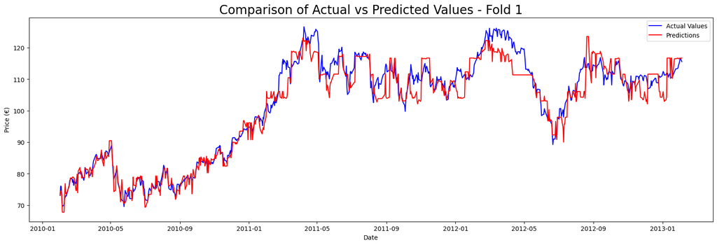

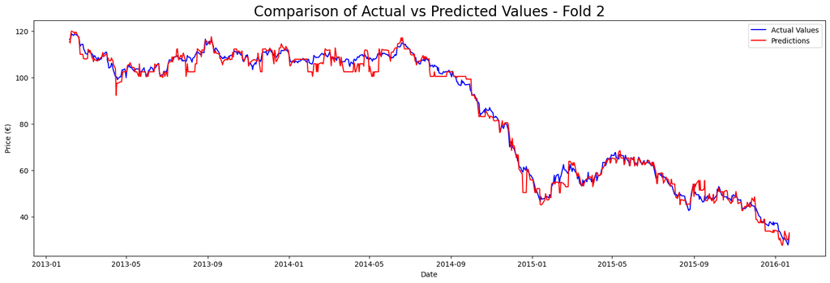

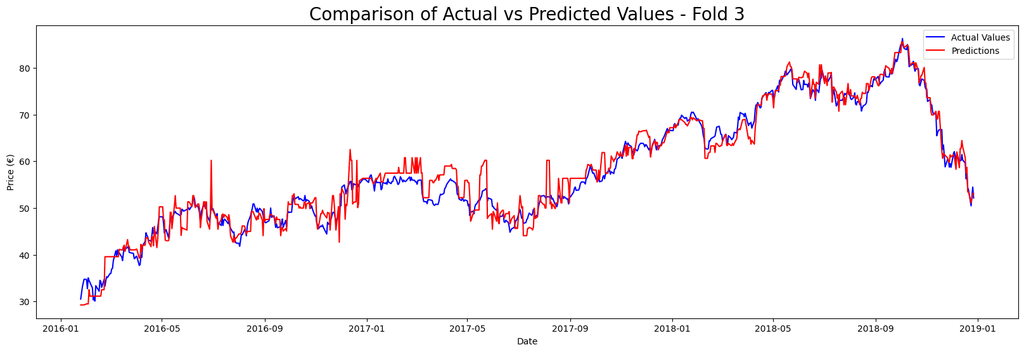

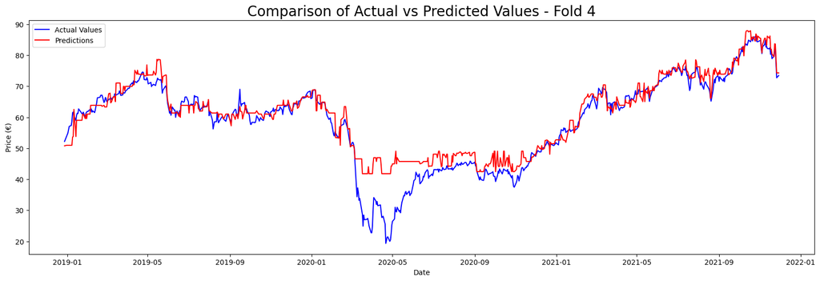

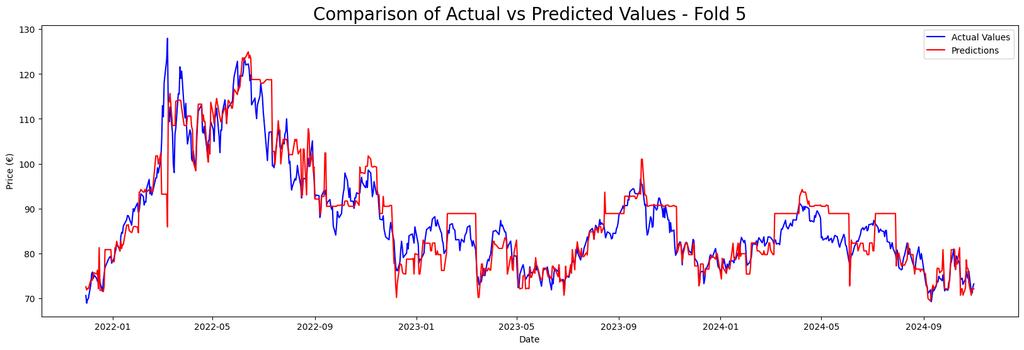

```
fold n° 1
R2 :  0.9382679363411763
MSE :  15.500962467389332
MAE :  2.94548208580897
RMSE :  3.9371261685891312


fold n° 2
R2 :  0.9907973267874624
MSE :  6.668035350734686
MAE :  1.9346604917360388
RMSE :  2.582253928399507


fold n° 3
R2 :  0.9646232592466776
MSE :  5.3345942499702925
MAE :  1.791209075761878
RMSE :  2.309674057084742


fold n° 4
R2 :  0.8714821865973155
MSE :  25.720542406761155
MAE :  3.140285349410513
RMSE :  5.071542409046892


fold n° 5
R2 :  0.8530756113067137
MSE :  20.00967623369244
MAE :  3.1057479692542036
RMSE :  4.473217659995145


Average R2: 0.9236492640558691
Average mse: 14.646762141709582
Average mae: 2.5834769943943203
Average rmse: 3.6747628446230833
```

```python
# We split the dataset into two: one X for the features and one Y for the variable we want to predict
X,y = df_brent_pre_pro.drop(columns=['Adj Close']), df_brent_pre_pro['Adj Close']

test = True
scores=kfoldCrossValidation(X,y,decision_tree,best_k,test);

# Print the results for each fold
for i in range(0,best_k):
  print("fold n°",i+1)
  print("R2 : ",scores[0][i])
  print("MSE : ",scores[1][i])
  print("MAE : ",scores[2][i])
  print("RMSE : ",scores[3][i])
  print("\n")

# Average R²
average_accuracy = sum(scores[0]) / len(scores[0])
print(f"Average R2: {average_accuracy}")

# Average MSE
average_accuracy_mse = sum(scores[1]) / len(scores[1])
print(f"Average mse: {average_accuracy_mse}")


# Average MAE
average_accuracy_mae = sum(scores[2]) / len(scores[2])
print(f"Average mae: {average_accuracy_mae}")


# Average RMSE
average_accuracy_rmse = sum(scores[3]) / len(scores[3])
print(f"Average rmse: {average_accuracy_rmse}")
```

**the model achieved its best performance with k=5, maximizing the average R² score.**

**By using the k-cross validation, we made sure that the performance metrics are not biased by a single train-test split, providing a reliable assessment of the model’s generalization.**

**This analysis confirms that the Decision Tree Regressor performs well under k-cross validation, particularly when k=5, offering a balance between training data size and test set diversity.**

**However, the values of the error metrics highlight the potential limitations of a Decision Tree Regressor’s tendency to overfit, as seen in earlier analyses.**

# **Stage 1 Conclusion**

**After implementing and evaluating three models—Linear Regression, Decision Tree Regressor, and Decision Tree with K-Cross Validation—we observed significant differences in their performance metrics.**

**The Linear Regression model is by far the most accurate among the three. It provided the best R2 score for explaining price variance and had relatively low error metrics (MSE, MAE, RMSE). While its simplicity makes it robust against overfitting, it may not fully capture the abrupt shocks or regime switches that can characterize Brent oil price dynamics, limiting its predictive power in more complex scenarios.**

**As we can see with the plot of real vs predicted prices, the Decsion Tree Regressor struggles a lot more with oil price predictions. It demonstrated excellent training set performance but performed poorly on the test set, which is a sign of overfitting.**

**Using K-Cross Validation improved the Decision Tree's robustness and accuracy, particularly in terms of generalization capability (higher average R2 score). However, this improvement came with increased variability in error metrics, and the method alone did not fully resolve the overfitting issues inherent in the Decision Tree model.**

**Therefore, we will have to improve these models or introduce more advanced models if we want to reach our goal of providing the most accurate oil price forecasts.**

# **Stage 2**

In the Stage 2, we decided to implement the k-neirest neighbors algorithm on our dataset to improve our predictions.

```python
from sklearn.neighbors import KNeighborsRegressor
from sklearn.model_selection import train_test_split
from sklearn.preprocessing import StandardScaler
from sklearn.metrics import r2_score, mean_squared_error, mean_absolute_error
from sklearn.model_selection import GridSearchCV
```

```python
# We split the dataset into two: one X for the features and one Y for the variable we want to predict
X,y = df_brent_pre_pro.drop(columns=['Adj Close']), df_brent_pre_pro['Adj Close']
```

After conducting several manual tests classified based on different metrics, we decided to use a training split size of 0.6.

```python
# Division des données
# Split training and test set
split_index = int(len(X) * 0.6)  # Split index with best size (90%)

# Split training and test set
X_train, X_test = X[:split_index], X[split_index:]
y_train, y_test = y[:split_index], y[split_index:]

# Normalisation des données pour améliorer les performances du k-NN
scaler = StandardScaler()
X_train = scaler.fit_transform(X_train)
X_test = scaler.transform(X_test)
```

We use the function "GridSearchCV" with the model KNeighborsRegresor to optimize our parameters for the k-nearest neighbors model. First of all, the choice of "metric". The "metric" is how the distance in the model will be calculated for a test sample with all the train samples. We then decide the parameter k, which is the amount of nearest neighbors our model will consider "the nearest" (k lowest distance in between all the train samples) from our test sample. We decided to search in a wide choice of value. We estimate that the most optimize value of k must be almost surely in between 1 and 50.

```python
param_grid = {'n_neighbors': range(1, 50), 'metric': ['euclidean', 'manhattan']}
grid = GridSearchCV(KNeighborsRegressor(), param_grid, cv=5)
grid.fit(X_train, y_train)

print(f"Meilleurs paramètres : {grid.best_params_}")
```

```
Meilleurs paramètres : {'metric': 'manhattan', 'n_neighbors': 6}
```

The GridSearchCV function rank all its results based on the r2 score metric. In other words, the ouput of the function is composed of the combinaison of parameters that gives the best r2 score metric. Here we have the type of distance "manhattan" and k=6 that we apply to our code on the cell just down this text.

```python
# Modèle k-NN pour la régression
knn_reg = KNeighborsRegressor(n_neighbors=6, metric = 'manhattan')
knn_reg.fit(X_train, y_train)

# Prédiction
y_pred_knn = knn_reg.predict(X_test)

# Convert y_pred into a DataFrame with the same index as x_test to keep the dates
y_pred_knn_df = pd.DataFrame(y_pred_knn, index=y_test.index, columns=['Prix_Prédit'])
```

We observe our four metrics after predicting the test samples with our optimized model in the variable y_pred_knn.

```python
# Quantify the errors
R2_score = r2_score(y_test, y_pred_knn)

mse_linear_regression = mean_squared_error(y_test, y_pred_knn)
mae = mean_absolute_error(y_test, y_pred_knn)
rmse = root_mean_squared_error(y_test, y_pred_knn)

print("R2 : ", R2_score)
print("MSE : ", mse_linear_regression)
print("MAE : ",mae)
print("RMSE : ",rmse)
```

```
R2 :  0.8922229519151854
MSE :  39.97170067663038
MAE :  4.686657549272595
RMSE :  6.32231766653894
```

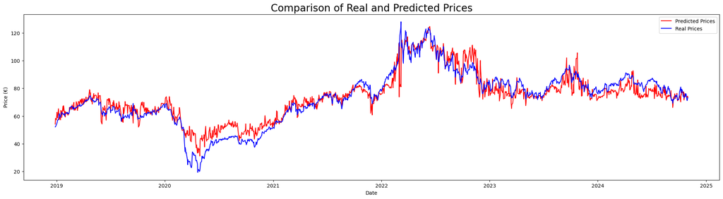

```python
# Plot Real and predicted prices together for comparison
plt.figure(figsize=(25, 6))

#plt.plot(y_test, label='Real Prices', color='black')
plt.plot(y_pred_knn_df, label='Predicted Prices', color='red')
plt.plot(y_test, label='Real Prices', color='blue')
plt.xlabel('Date')
plt.ylabel('Price (€)')
plt.title('Comparison of Real and Predicted Prices',size=20)
plt.legend()
plt.show()
```

The graph above represents the prediction on the test sample in red, compared to the actual price values. Overall, we observe that the prediction curve closely follows the trend of the real prices, indicating relatively low variance. However, there are instances where the prediction curve deviates slightly from the actual price curve. This suggests the presence of some bias, which is also reflected in our evaluation metrics.

## **ENSEMBLE LEARNING**

After testing a few simple models, we decided to take it a step further by combining them to amplify their strengths and minimize their weaknesses. This approach is known as **ENSEMBLE LEARNING**.

## **Bagging**

We first decided to combine our k-nearest neighbors model and our decision tree regressor. For the **Bagging technique**, we simply average the predictions from each model. In this case, we predict prices by taking the average of the k-nearest neighbors predictions and the decision tree predictions.

We did not use the same test size for each model initially due to the optimization of metrics. To ensure comparability, we decided to reduce the larger test size (k-nearest neighbors: 0,4) to match the smaller one (decision tree: 0,1).

```python
#bagging in between knn and tree
y_pred_knn_tree = (y_pred_knn_df + y_pred_tree_df)/2
y_pred_knn_tree = y_pred_knn_tree.dropna()

# Réinitialiser l'index pour inclure "Date" comme colonne
y_test = df_brent[["Adj Close"]].iloc[-369:]

# Quantify the errors
R2_score = r2_score(y_test, y_pred_knn_tree)

mse = mean_squared_error(y_test, y_pred_knn_tree)
mae = mean_absolute_error(y_test, y_pred_knn_tree)
rmse = root_mean_squared_error(y_test, y_pred_knn_tree)

print("R2 : ", R2_score)
print("MSE : ", mse)
print("MAE : ",mae)
print("RMSE : ",rmse)
```

```
R2 :  0.7509752828382503
MSE :  7.686511789860859
MAE :  2.3045010579633836
RMSE :  2.77245591305991
```

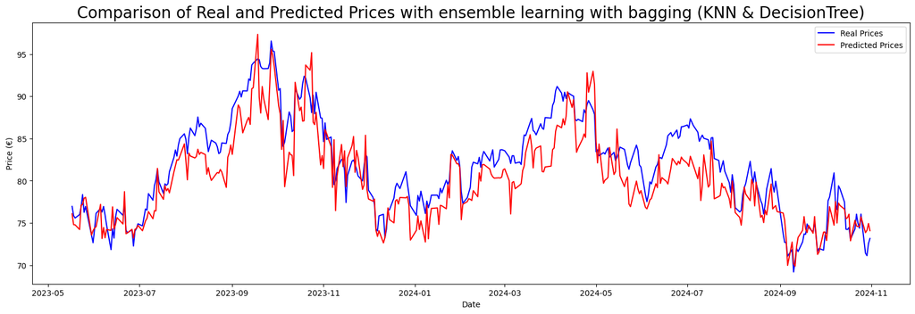

```python
# Plot Real and predicted prices together for comparison
plt.figure(figsize=(20, 6))

plt.plot(y_test, label='Real Prices', color='blue')
plt.plot(y_pred_knn_tree, label='Predicted Prices', color='red')

plt.xlabel('Date')
plt.ylabel('Price (€)')
plt.title('Comparison of Real and Predicted Prices with ensemble learning with bagging (KNN & DecisionTree)',size=20)
plt.legend()
plt.show()
```

## **Stacking**

We then decided to combine our k-nearest neighbors model and our decision tree regressor with a static technique. The goal of this method is to improve predictive performance by leveraging the strengths of different types of models. To reach this goal, the predictions from the base models are used as inputs for a meta-model (a second-level model, in our case we chosed a linear regression model) that learns to make the final prediction.

We optimized the stacking model's performance by combining overfitting control and hyperparameters optimization. We used a grid search function to find the best hyperparameters for each base models, and we split the dataset into different training sizes ranging from 50% to 90% of the data to find the optimal balance between R2 score and MSE.

```python
from sklearn.ensemble import StackingRegressor
from sklearn.linear_model import Ridge
```

```python
# We split the dataset into two: one X for the features and one Y for the variable we want to predict
X,y = df_brent_pre_pro.drop(columns=['Adj Close']), df_brent_pre_pro['Adj Close']

# Division des données
# Different training sizes to test for overfitting control (from 50% to 90% of the data for training)
train_sizes = [0.5, 0.6, 0.7, 0.8, 0.9]
results = []

# Initialiser un DataFrame vide pour stocker les prédictions filtrées
filtered_predictions = pd.DataFrame()

for train_size in train_sizes:
  # Split training and test set
  split_index = int(len(X) * train_size)

  # Split training and test set
  X_train, X_test = X[:split_index], X[split_index:]
  y_train, y_test = y[:split_index], y[split_index:]
  print()
  print(train_size)
  # Grid Search for KNeighborsRegressor
  param_grid = {'n_neighbors': range(4, 20), 'metric': ['euclidean', 'manhattan']}
  grid = GridSearchCV(KNeighborsRegressor(), param_grid, cv=5)
  grid.fit(X_train, y_train)
  print(f"Meilleurs paramètres : {grid.best_params_}")

  # Grid Search for DecisionTreeRegressor
  param_grid_tree = {'max_depth': range(3, 26)}
  grid_tree = GridSearchCV(DecisionTreeRegressor(random_state=42), param_grid_tree, cv=5)
  grid_tree.fit(X_train, y_train)
  print(f"Decision Tree - Meilleurs paramètres : {grid_tree.best_params_}")

  # Définir les modèles de base
  base_models = [
      ('knn', KNeighborsRegressor(n_neighbors=grid.best_params_["n_neighbors"], metric = grid.best_params_["metric"])),
      ('lr', DecisionTreeRegressor(max_depth=grid_tree.best_params_["max_depth"]))
  ]


  # Une régression linéaire régularisée en méta-modèle
  meta_model = Ridge()

  # Stacking regressor model
  stacking = StackingRegressor(estimators=base_models, final_estimator=meta_model)

  # Entraîner le modèle
  stacking.fit(X_train, y_train)

  # Prédire et évaluer
  y_pred_stacking = stacking.predict(X_test)

  # Convert y_pred into a DataFrame with the same index as x_test to keep the dates
  y_pred_stacking_df = pd.DataFrame(y_pred_stacking, index=y_test.index, columns=['Prix_Prédit'])

  # Quantify the errors
  R2_score = r2_score(y_test, y_pred_stacking)

  mse = mean_squared_error(y_test, y_pred_stacking)





  print("R2 : ", R2_score)
  print("MSE : ", mse)
  print( )
```

```
0.5
```

```
Meilleurs paramètres : {'metric': 'euclidean', 'n_neighbors': 7}
```

```
Decision Tree - Meilleurs paramètres : {'max_depth': 19}
R2 :  0.8677547400015053
MSE :  42.25628795851067


0.6
Meilleurs paramètres : {'metric': 'euclidean', 'n_neighbors': 4}
Decision Tree - Meilleurs paramètres : {'max_depth': 11}
R2 :  0.9324384320018287
MSE :  25.05682630258649


0.7
Meilleurs paramètres : {'metric': 'euclidean', 'n_neighbors': 7}
Decision Tree - Meilleurs paramètres : {'max_depth': 14}
R2 :  0.947245055985011
MSE :  16.944232927709667


0.8
Meilleurs paramètres : {'metric': 'euclidean', 'n_neighbors': 7}
Decision Tree - Meilleurs paramètres : {'max_depth': 11}
R2 :  0.8541335392810917
MSE :  19.87693588920444


0.9
Meilleurs paramètres : {'metric': 'euclidean', 'n_neighbors': 18}
Decision Tree - Meilleurs paramètres : {'max_depth': 13}
R2 :  0.8513070221969674
MSE :  4.589626041860572
```

```python
# Split training and test set
split_index = int(len(X) * 0.7)  # Split index with best size (70%)

  # Split training and test set
X_train, X_test = X[:split_index], X[split_index:]
y_train, y_test = y[:split_index], y[split_index:]



  # Définir les modèles de base
base_models = [
      ('knn', KNeighborsRegressor(n_neighbors= 7 , metric = 'euclidean')),
      ('lr', DecisionTreeRegressor(max_depth=14))
]

  # Méta-modèle
meta_model = Ridge()  # Une régression linéaire régularisée en méta-modèle

  # Stacking Regressor
stacking = StackingRegressor(estimators=base_models, final_estimator=meta_model)

  # Entraîner le modèle
stacking.fit(X_train, y_train)

  # Prédire et évaluer
y_pred_stacking = stacking.predict(X_test)

  # Convert y_pred into a DataFrame with the same index as x_test to keep the dates
y_pred_stacking_df = pd.DataFrame(y_pred_stacking, index=y_test.index, columns=['Prix_Prédit'])

  # Quantify the errors
R2_score = r2_score(y_test, y_pred_stacking)

mse = mean_squared_error(y_test, y_pred_stacking)
print(R2_score,mse)
```

```
0.9453385395002504 17.556582348251624
```

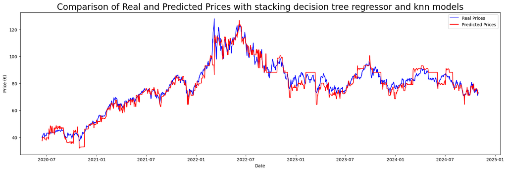

```python
# Plot Real and predicted prices together for comparison
plt.figure(figsize=(20, 6))

plt.plot(y_test, label='Real Prices', color='blue')
plt.plot(y_pred_stacking_df, label='Predicted Prices', color='red')

plt.xlabel('Date')
plt.ylabel('Price (€)')
plt.title('Comparison of Real and Predicted Prices with stacking decision tree regressor and knn models',size=20)
plt.legend()
plt.show()
```

The best training size to mitigate overfitting without compromising the performance was identified at 70%.

This strong accuracy achieved by the stacking method can be attributed to its underlying principle. As we saw before, the decision tree model produces low prediction errors but struggles a lot to capture the variance in the data. On the other side, the KNN model provides a better explanation of the data’s variance but has higher prediction errors. By combining these models and weighting there values with another model, we can leverage their strengths while mitigating their weakness.

However, from a business perspective, these results may still not be good enough for practical use. To improve prediction accuracy, we could explore alternative approaches, such as using neural networks with deep learning models.

# Stage 3

For the final stage, we decided to go deeper into our project. We first implemented a more complexe ensemble learning algorithm named XGBoost. We then implemented an algorithm of deep learning improve all of our results. This algorithm is called GA-SVR-GRNN.

### XGBoost

```python
import xgboost as xgb
from sklearn.model_selection import RandomizedSearchCV
```

We first split the dataset into X for the explicative variables and Y for the predictive variable with a train size of 0.7.

```python
# We split the dataset into two: one X for the features and one Y for the variable we want to predict
X,y = df_brent_pre_pro.drop(columns=['Adj Close']), df_brent_pre_pro['Adj Close']

# Split training and test set
split_index = int(len(X) * 0.7)  # Split index with best size (70%)

  # Split training and test set
X_train, X_test = X[:split_index], X[split_index:]
y_train, y_test = y[:split_index], y[split_index:]
```

We then create then model and search for the best hyperparameters. We are testing a couple of values max_depth for the depth of each tree, learning_rate for how the weights will be updated, n_estimators for the number of trees to build, subsample for the fractrion of training samples for building each tree, colsample_bytree for the fraction of columns randomly selected to construct each tree and finally the hyperparameter gamma which is the minimum loss reduction to make another node.

We decided to use the function RandomizedSearch instead of GridSearch to improve the time of research.

```python
# Création du modèle XGBoost Regressor
xgb_model = xgb.XGBRegressor(objective='reg:squarederror')

# Définition de la grille d'hyperparamètres à tester
param_grid = {
    'max_depth': [3, 5, 7],
    'learning_rate': [0.01, 0.1, 0.2],
    'n_estimators': [50, 100, 200],
    'subsample': [0.8, 1.0],
    'colsample_bytree': [0.8, 1.0],
    'gamma': [0, 1, 5]
}

# Configuration de la RandomizedSearchCV
random_search = RandomizedSearchCV(
    estimator=xgb_model,
    param_distributions=param_grid,
    n_iter=50,  # Nombre d'itérations à tester
    scoring='neg_mean_squared_error',  # Nous voulons minimiser l'erreur quadratique
    cv=5,  # Validation croisée à 5 plis
    verbose=1,
    random_state=42
)
```

We then fit and predict as usual with our best version of XGBoost model after the randomizedSearchCV. We evaluate our model with our usual metrics.

```python
# Entraînement du modèle
random_search.fit(X_train, y_train)

# Prédictions
y_pred_xgb = random_search.predict(X_test)

y_pred_stacking_df = pd.DataFrame(y_pred_xgb, index=y_test.index, columns=['Prix_Prédit'])


# Évaluation
R2_score = r2_score(y_test, y_pred_xgb)
mse = mean_squared_error(y_test, y_pred_xgb)
mae = mean_absolute_error(y_test, y_pred_xgb)
rmse = root_mean_squared_error(y_test, y_pred_xgb)

print("R2 : ", R2_score)
print("MSE : ", mse)
print("MAE : ",mae)
print("RMSE : ",rmse)
```

```
Fitting 5 folds for each of 50 candidates, totalling 250 fits
R2 :  0.984873209256288
MSE :  4.8585373484114465
MAE :  1.5931658714605132
RMSE :  2.2042090074245335
```

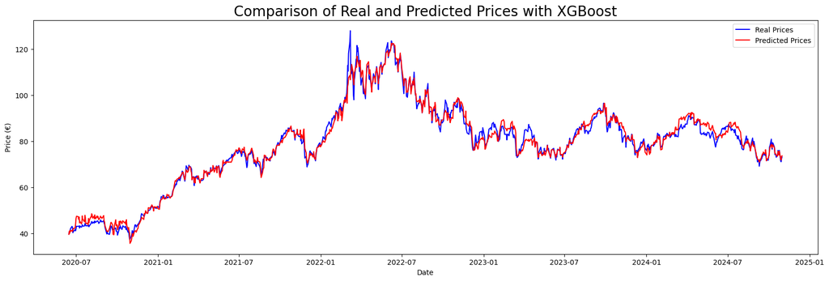

```python
#Plot Real and predicted prices together for comparison
plt.figure(figsize=(20, 6))

plt.plot(y_test, label='Real Prices', color='blue')
plt.plot(y_pred_stacking_df, label='Predicted Prices', color='red')

plt.xlabel('Date')
plt.ylabel('Price (€)')
plt.title('Comparison of Real and Predicted Prices with XGBoost',size=20)
plt.legend()
plt.show()
```

For the XGBoost model we can observe with the metrics and the graph some really good results. Concerning the variance the predictive curve is quite accurate in term of trend but we can see some struggles to follow the big movement. Nevertheless, in term of bias the graph seems pretty accurate in the space. It rarely misplaced the prediction.

### GA-SVR-GRNN

In the last part of this project, we decided to implement a GA-SVR-GRNN hybrid model, which combines 3 distinct algorithms : Genetic Algorithms (GA), Support Vector Regression (SVR), and General Regression Neural Networks (GRNN). The process involves hyperparameter optimization, residual correction, and obviously the use of deep learning techniques.

```python
import numpy as np
from sklearn.svm import SVR
from sklearn.metrics import mean_squared_error, r2_score
from deap import base, creator, tools, algorithms
import tensorflow as tf
from tensorflow.keras import layers, models
from sklearn.preprocessing import StandardScaler
```

Like before, we split the dataset into X for the explicative variables and Y for the predictive variable with a train size of 0.7.

```python
# We split the dataset into two: one X for the features and one Y for the variable we want to predict
X,y = df_brent_pre_pro.drop(columns=['Adj Close']), df_brent_pre_pro['Adj Close']

# Split training and test set
split_index = int(len(X) * 0.7)  # Split index with best size (70%)

  # Split training and test set
X_train, X_test = X[:split_index], X[split_index:]
y_train, y_test = y[:split_index], y[split_index:]
```

The first part of this hybrid model focuses on employing a genetic algorithm to optimize the hyperparameters of the SVR model. The algorithm iteratively refines parameters such as the penalty C, the insensitivity loss epsilon, and the RBF kernel parameter gamma, with the objective of minimizing the Mean Squared Error (MSE) as fitness function on the test data. The process involves generating a population of random solutions, evaluating their performance, and evolving them through selection, crossover, and mutation. We ensure that the parameters generated at each test are always positive because the SVR model can only take positive parameters.

```python
# --- 1. Création de l'algorithme génétique pour optimiser les hyperparamètres de SVR ---
creator.create("FitnessMin", base.Fitness, weights=(-1.0,))  # Minimiser l'erreur
creator.create("Individual", list, fitness=creator.FitnessMin)

# Définition de la fonction d'évaluation (utilise un SVR avec les hyperparamètres donnés)
def evalSVR(individual):
    C, epsilon, gamma = individual
    svr = SVR(C=max(C,0.1), epsilon=max(epsilon,0.01), kernel='rbf', gamma=max(gamma,0.001))
    svr.fit(X_train, y_train)
    y_pred = svr.predict(X_test)
    mse = mean_squared_error(y_test, y_pred)
    return mse,  # la virgule indique que c'est un tuple

# Initialisation de l'algorithme génétique
toolbox = base.Toolbox()
toolbox.register("attr_float", np.random.uniform, 0.1, 100)  # Plage de C
toolbox.register("attr_epsilon", np.random.uniform, 0.01, 5)  # Plage de epsilon
toolbox.register("attr_gamma", np.random.uniform, 0.001, 5)  # Plage de gamma
toolbox.register("individual", tools.initCycle, creator.Individual, (toolbox.attr_float, toolbox.attr_epsilon, toolbox.attr_gamma), n=1)
toolbox.register("population", tools.initRepeat, list, toolbox.individual)
toolbox.register("mate", tools.cxBlend, alpha=0.5)
toolbox.register("mutate", tools.mutGaussian, mu=0, sigma=1, indpb=0.2)
toolbox.register("select", tools.selTournament, tournsize=3)
toolbox.register("evaluate", evalSVR)

# Création de la population initiale
population = toolbox.population(n=10)

# Exécution de l'algorithme génétique
algorithms.eaSimple(population, toolbox, cxpb=0.7, mutpb=0.2, ngen=10, verbose=True)
```

```
gen	nevals
0  	10
1  	9
2  	4
3  	10
4  	10
5  	7
6  	9
7  	8
8  	6
9  	10
10 	7
```

```
([[50.78432391245452, 2.593175675931965, 2.104889989159944],
  [50.784323912454525, 2.593175675931965, 2.104889989159944],
  [50.784323912454525, 2.593175675931965, 2.104889989159944],
  [50.78432391245452, 2.593175675931965, 2.104889989159944],
  [50.62461602554613, 2.600331203056966, 2.1458557884391576],
  [51.326346638912085, 2.604374706052637, 2.085122328917949],
  [50.78432391245452, 3.629974388137244, 0.03700897615821619],
  [50.76815049963072, 2.603563195762482, 2.0953334250516984],
  [50.784323912454525, 2.593175675931965, 2.104889989159944],
  [50.784323912454525, 2.593175675931965, 2.104889989159944]],
 [{'gen': 0, 'nevals': 10},
  {'gen': 1, 'nevals': 9},
  {'gen': 2, 'nevals': 4},
  {'gen': 3, 'nevals': 10},
  {'gen': 4, 'nevals': 10},
  {'gen': 5, 'nevals': 7},
  {'gen': 6, 'nevals': 9},
  {'gen': 7, 'nevals': 8},
  {'gen': 8, 'nevals': 6},
  {'gen': 9, 'nevals': 10},
  {'gen': 10, 'nevals': 7}])
```

Once the optimal SVR parameters are identified, the model is trained on the training set and tested on the test set. Predictions are made, and residuals (the differences between the predicted and actual values) are computed. These residuals highlight errors in the initial SVR predictions, which are addressed in the next stage.

```python
# --- 2. Récupération des meilleurs hyperparamètres et création du modèle SVR optimal ---
best_individual = tools.selBest(population, 1)[0]
C, epsilon, gamma = best_individual
print(f"Best SVR parameters: C={C}, epsilon={epsilon}, gamma={gamma}")

# Entraînement du modèle SVR avec les meilleurs paramètres
svr_best = SVR(C=max(C,0.1), epsilon=max(epsilon,0.01), kernel='rbf', gamma=max(gamma,0.001))
svr_best.fit(X_train, y_train)

# Prédictions avec SVR
y_pred_svr = svr_best.predict(X_test)

# Calcul des résidus
residuals = y_test - y_pred_svr

# Calcul de l'erreur quadratique moyenne (MSE) avant ajustement avec GRNN
mse_SVR = mean_squared_error(y_test, y_pred_svr)
print(f"Mean Squared Error with SVR: {mse_SVR}")
```

```
Best SVR parameters: C=50.62461602554613, epsilon=2.600331203056966, gamma=2.1458557884391576
Mean Squared Error with SVR: 321.1875825893753
```

In the last part, the residuals are modeled and corrected using a GRNN model. The GRNN learns to predict these residuals based on a neural network using regression. To improve its performance, the input features are normalized before training. The GRNN predictions are then added to the initial SVR predictions to produce the final forecast. We finally evaluate the performance of this hybrid model with two metrics : MSE and R2 score.

```python
# --- 3. Entraînement d'un modèle GRNN sur les résidus ---
# Création d'un modèle de réseau neuronal pour la régression des résidus
def create_grnn_model():
    model = models.Sequential()
    model.add(layers.Dense(64, activation='relu', input_dim=X_train.shape[1]))  # Couche cachée
    model.add(layers.Dense(32, activation='relu'))  # Couche cachée
    model.add(layers.Dense(1))  # Sortie
    model.compile(optimizer='adam', loss='mse')
    return model

# Normalisation des données pour améliorer les performances
scaler = StandardScaler()
X_train = scaler.fit_transform(X_train)
X_test = scaler.transform(X_test)

# Entraînement du GRNN sur les résidus
grnn = create_grnn_model()
grnn.fit(X_test, residuals, epochs=50, batch_size=16, verbose=0)

# Prédictions des résidus avec GRNN
residual_preds = grnn.predict(X_test).flatten()

# Ajustement des prédictions SVR avec les résidus du GRNN
final_predictions = y_pred_svr + residual_preds

# Calcul de l'erreur quadratique moyenne (MSE) après ajustement
mse_final = mean_squared_error(y_test, final_predictions)
print(f"Mean Squared Error after GRNN adjustment: {mse_final}")

#Calcul du R2 score
R2_score = r2_score(y_test, final_predictions)
print("R2 : ", R2_score)
```

```
35/35 ━━━━━━━━━━━━━━━━━━━━ 0s 2ms/step
Mean Squared Error after GRNN adjustment: 0.07965520383038163
R2 :  0.9997519978722847
```

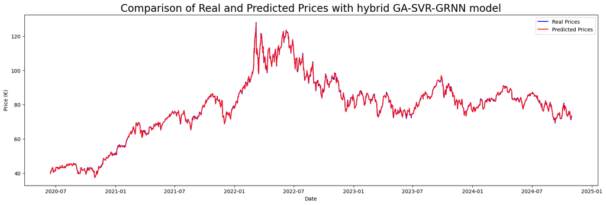

```python
final_predictions_df = pd.DataFrame(final_predictions, index=y_test.index, columns=['Prix_Prédit'])

#Plot Real and predicted prices together for comparison
plt.figure(figsize=(20, 6))

plt.plot(y_test, label='Real Prices', color='blue')
plt.plot(final_predictions_df, label='Predicted Prices', color='red')

plt.xlabel('Date')
plt.ylabel('Price (€)')
plt.title('Comparison of Real and Predicted Prices with hybrid GA-SVR-GRNN model',size=20)
plt.legend()
plt.show()
```

By comparing the two evaluation metrics, MSE and R2 score, used to evaluate the performance of each model we implemented, we can clearly conclude that the GA-SVR-GRNN model significantly outperforms all others. Even the classic linear regression model, which was the first algorithm implemented and had been the strongest performer until now, is notably outperformed in terms of MSE.